# Week 2 Transcriptomics

Ane Kleiven

2024-09-12

## Answers to questions **1. Why do we log-transform data?** We log-transform to make the data more readable and stretched out. The log value spreads the values more evenly across the value range, this will often give a normal distribution. On a linear scale, most of the values will be close to zero with outliers with high values. Log transformation makes the data more symmetrical. **Many scaling methods (i.e. normalisation for library size in RNA-Seq data) assume that most genes are not differentially expressed. Why is this a necessary assumption for methods such as DESeq2 and edgeR/TMM?** An assumption used in the methods is that the values are not differentially expressed. This is done to make the gene expression more similar across samples. Genes with low expression will be upscaled, genes with high expression will be downscaled. The assumption is necessary to make the methods work. If the majority of genes are not differentially expressed, the method will erase the systematical differences and keep the actual differences in the minority of differentially expressed genes. Makes the non-differentially expressed genes more similar. If most genes actually are different, the method will erase the differences. **3. Explain the intuition behind the EM-algorithm for estimating gene expression from multi-mapping reads. What is the problem that this algorithm is trying to solve and how does it solve it?** EM-algorithm is a method for assigning multireads probabilistically.The problem the algorithm is trying to solve, are the multi-mapping-reads, that could fit several isoforms. The algorithm predicts which read belongs to which isoform. The algorithm start by looking at the fraction of reads mapping to isoform 1 and 2 (theta 1 and 2) When we have an estimate of these thetas, we can find an estimate of tau (fraction of transcripts (mRNA) belonging to isoform i (the gene). The algorithm is iterative, and is improved by adding the multireads to the theta. This will give us a new tau. These steps are repeated until the result no longer changes. The end result is the probable distribution of the multi-reads.

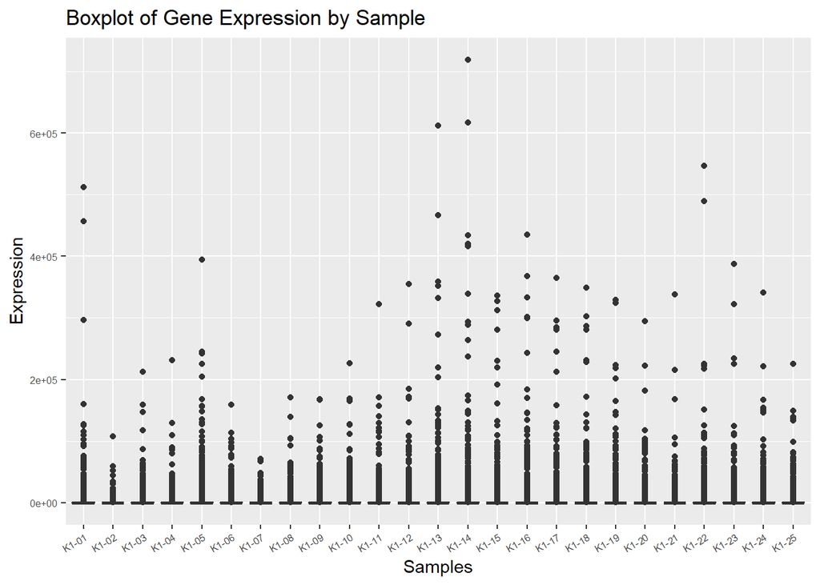

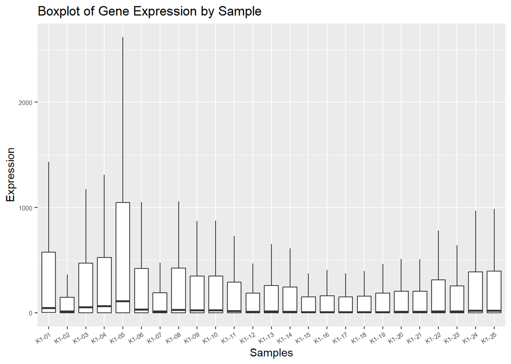

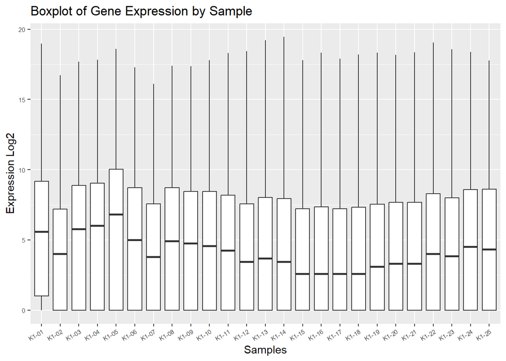

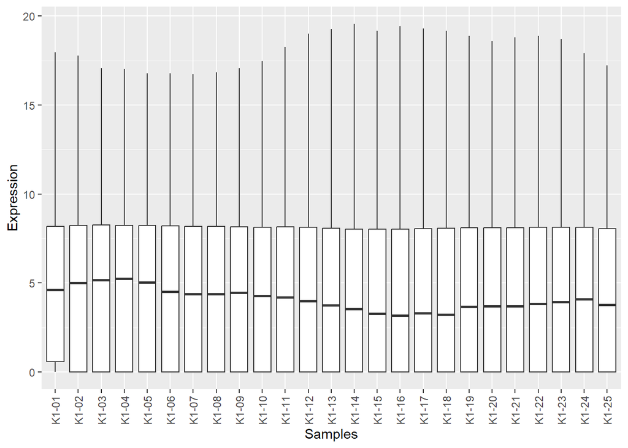

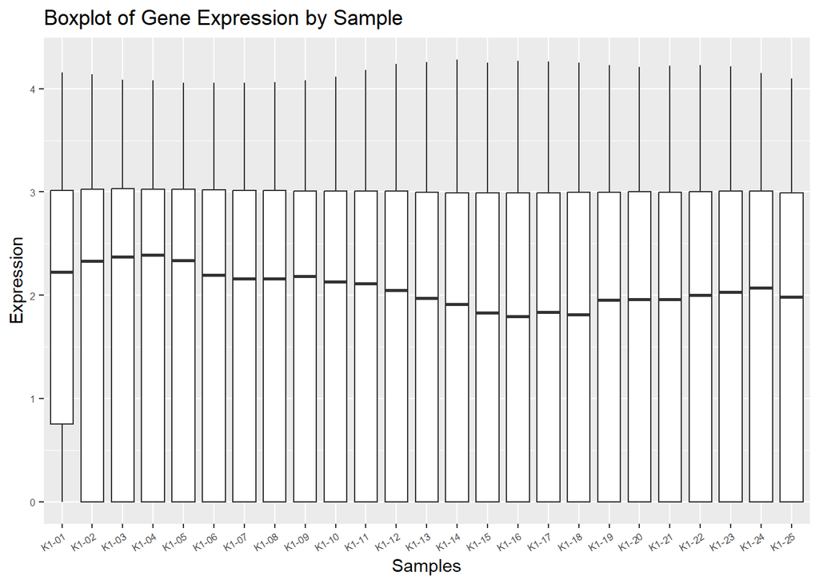

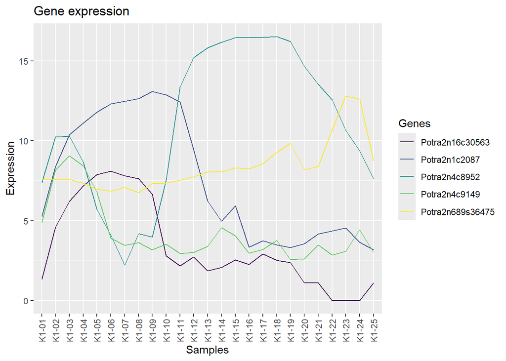